# Attud - Brief Report - Updated

Henrique Pinto Gomide

09-01-2015

# 1 Introduction

This is final report on the survey “International Needs for Treating Tobacco Use”. The survey aimed to understand the needs of tobacco treatment provider.

# 2 Methods

All tools used to collect, evaluate quality, analyze data were freeware or/and Open-source. For data collection we have used Ona (https://ona.io/), for data analysis R (R Core Team, 2015) using ggplot2 and sjPlot packages. This report was created using RMarkdown.

# 3 Results

## 3.1 Participants

The data reported here were collected from 159 valid cases. One case was considered invalid (test submission), thus removed. Most of participants were women 60.4% with mean age of 47.5 (SD = 11).

## 3.2 Profession

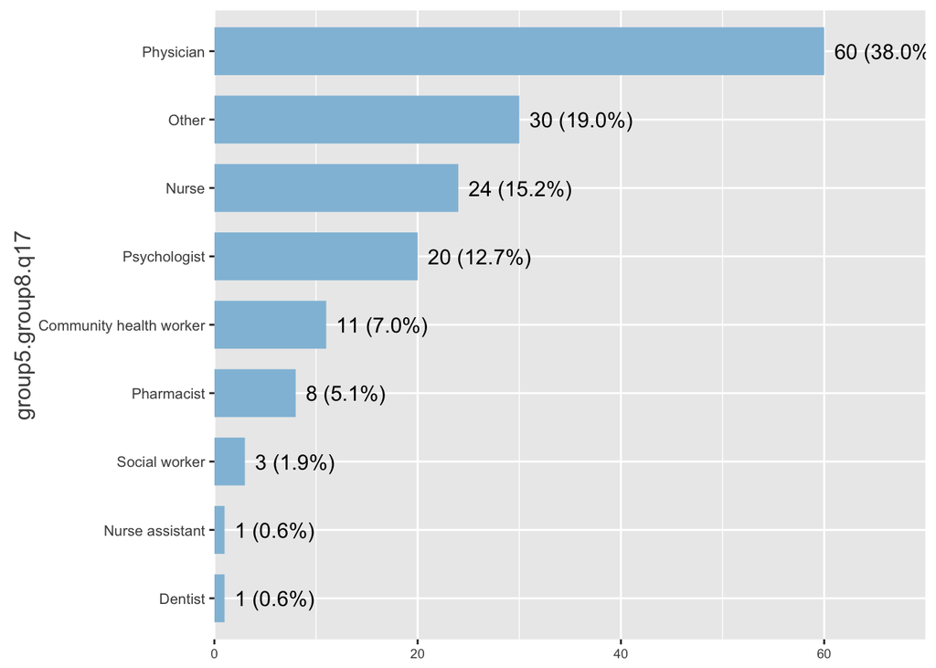

## 3.4 Are you a member of Attud?

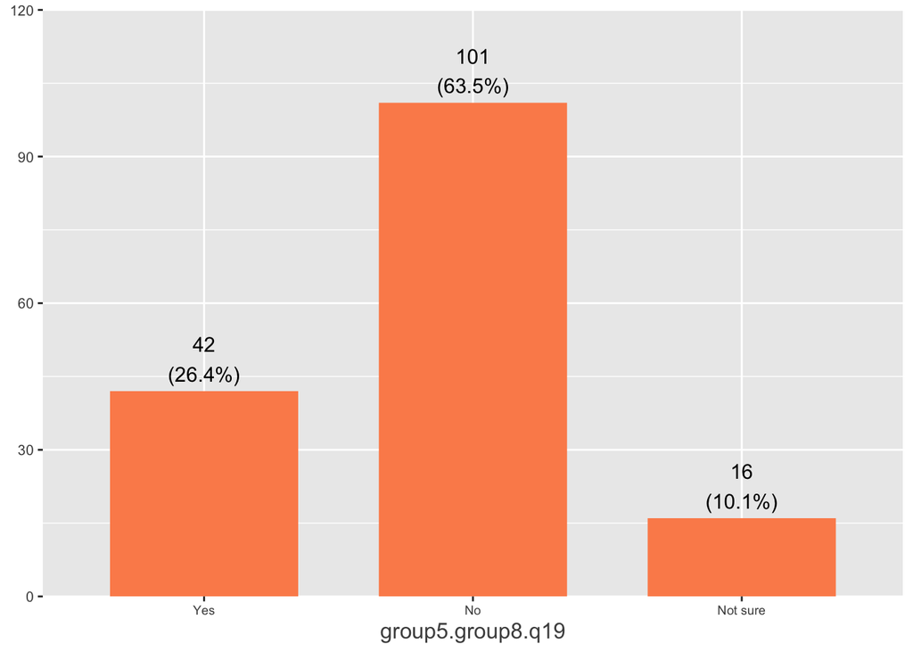

# 4 Practioner Role and Trainning

## 4.1 How did you learn how to treat tobacco dependence?

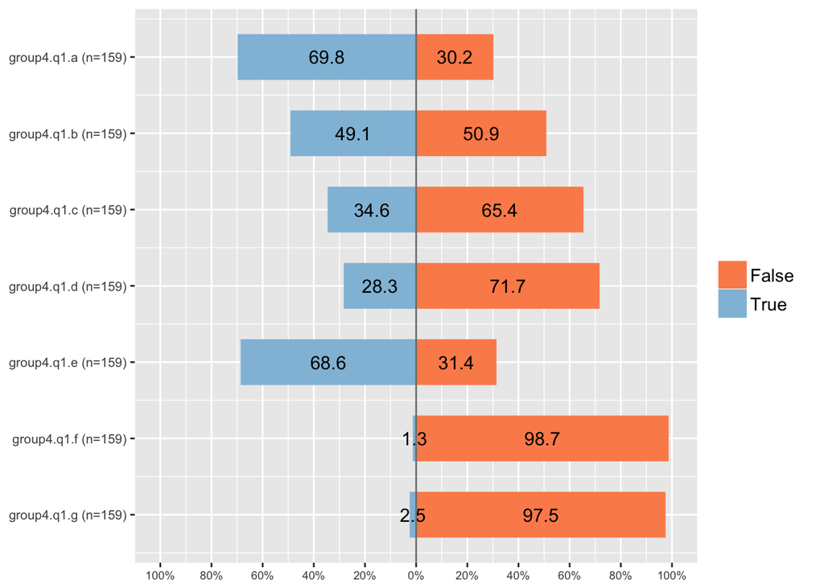

## 4.2 What tobacco treatment activities do you currently perform?

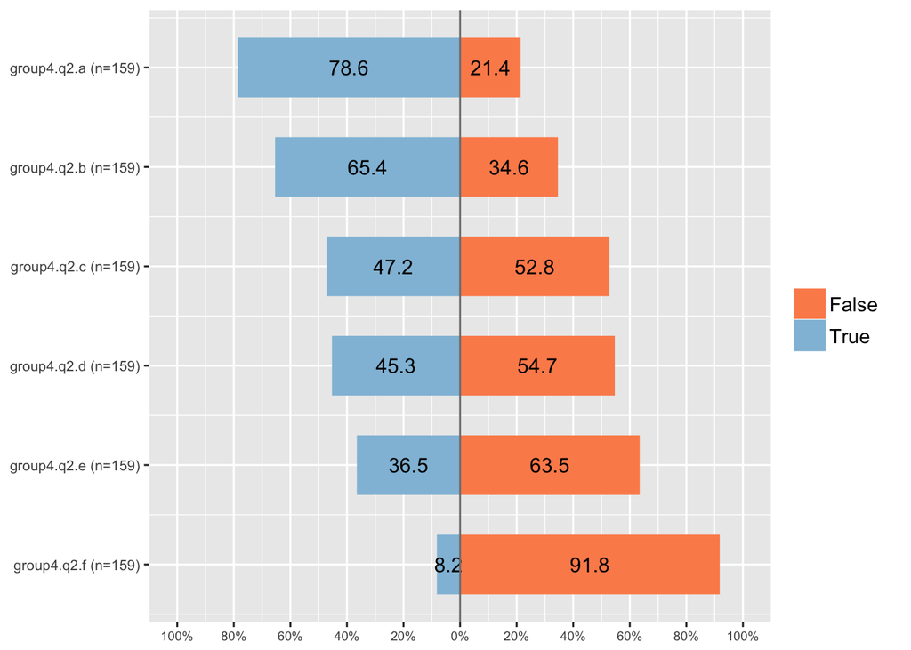

# 5 Tobacco Treatment Training in Your Country

## 5.1 Think back to your professional training curriculum. About how many hours of instruction in how to treat tobacco dependence were provided?

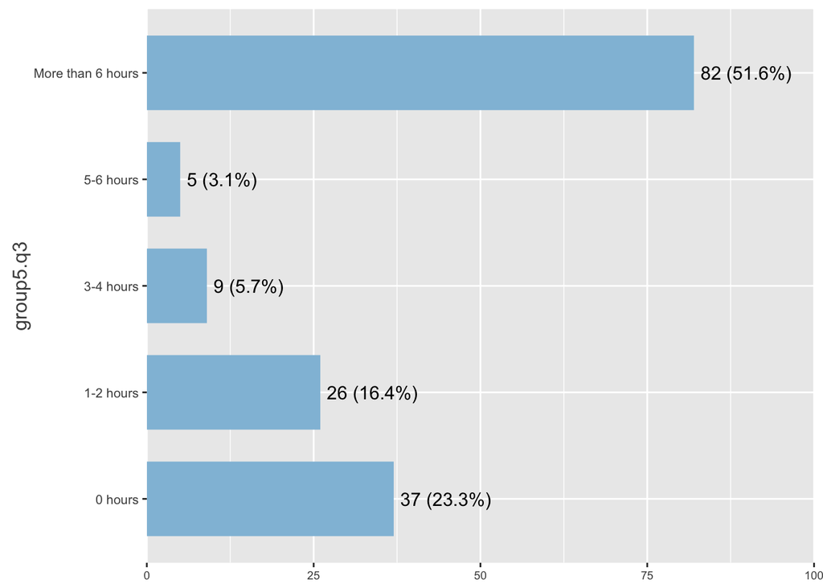

## 5.4 Overall, how would you rate the quality of the tobacco treatment training that is available in your country?

[figure not shown]

## 5.5 Does your country have any form of professional certification for tobacco treatment?

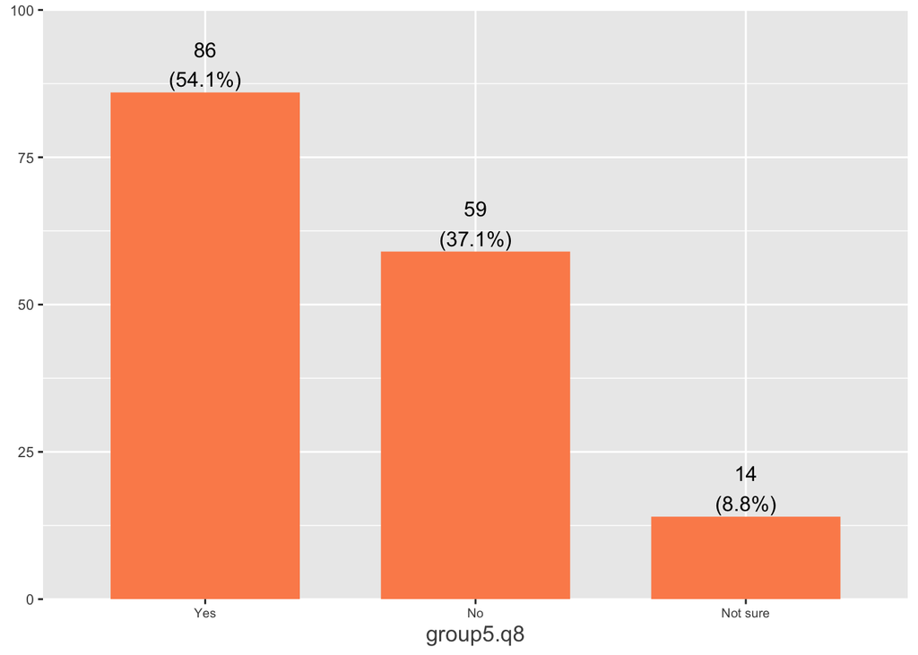

# 6 Guidelines for Tobacco Treatment

## 6.1 Does your country have national guidelines for the treatment of tobacco dependence?

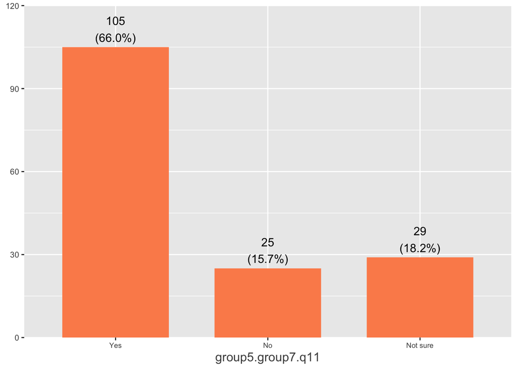

# 7 Survey Collection

## 7.1 Access over time

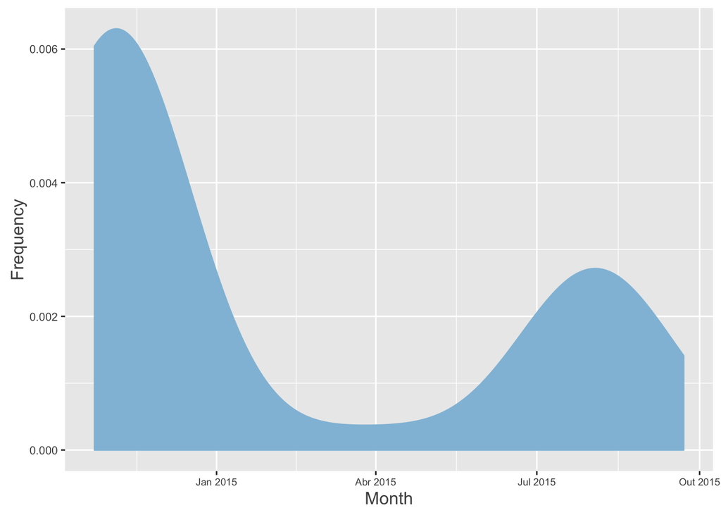

# 8 Countries

```r
## Import list with uncoded countries
uncoded  <- read.csv("R/uncodedCountries.csv")
## Import list with coded countries
coded <- read.csv("R/codedCountries.csv", col.names = c("code", "local_name"))
## Merge the two lists
listCountries  <- merge(coded, uncoded, by = "local_name")
## Table results from attud questionnaire
teste  <- as.data.frame(table(attud$group5.group8.q18))
## Pick good names for dataframe
colnames(teste) <- c("code", "Freq")
### Convert vars into character
teste$code  <- as.character(teste$code)
listCountries$code  <- as.character(listCountries$code)
listCountries$local_name  <- as.character(listCountries$local_name)
# Merge table and list of codes
table1  <- merge(teste, listCountries, by = "code")

# Subset the data for coutries that answered the survey at least once
table2  <- subset(table1, table1$Freq > 0)
# Create data from two variables - frequency and English name
finalCountryTable  <- table2[, c("Freq", "en_name", "region")]
# Sort the data
sorted  <- finalCountryTable[order(-finalCountryTable$Freq),  ]
print(sorted)
```

```
##    Freq                    en_name                            region
## 20   19 Taiwan (Republic of China)                      Eastern Asia
## 23   19                  Australia                         Australia
## 26   19              United States                     North America
## 43   11                      Spain                   Southern Europe
## 35    8                     Canada               North North America
## 41    7                    Ireland                   Northern Europe
## 13    6                  Argentina            Southern South America
## 29    6                     Israel         Middle East, Western Asia
## 4     5                      Egypt               Africa, Middle East
## 7     5                    Nigeria                       West Africa
## 32    4                      India                South-Central Asia
## 33    4                     Brazil     Central Eastern South America
## 3     3                   Malaysia                    Southeast Asia
## 36    3             Czech Republic                    Eastern Europe
```

[output cut: 31 more lines]

```r
# Row 13 is from Antarctica! What to do in this case?
write.csv(sorted, "freqTablebyCountry.csv")
```

```r
#Recode Income

attud$bank[attud$group5.group8.q18 == "a18"] <- "High income"
attud$bank[attud$group5.group8.q18 == "a183"] <- "High income"
attud$bank[attud$group5.group8.q18 == "a2"] <- "High income"
attud$bank[attud$group5.group8.q18 == "a192"] <- "High income"
attud$bank[attud$group5.group8.q18 == "a208"] <- "High income"
attud$bank[attud$group5.group8.q18 == "a171"] <- "High income"
attud$bank[attud$group5.group8.q18 == "a228"] <- "High income"
attud$bank[attud$group5.group8.q18 == "a22"] <- "High income"
attud$bank[attud$group5.group8.q18 == "a28"] <- "High income"
attud$bank[attud$group5.group8.q18 == "a45"] <- "High income"
attud$bank[attud$group5.group8.q18 == "a48"] <- "High income"
attud$bank[attud$group5.group8.q18 == "a47"] <- "High income"
attud$bank[attud$group5.group8.q18 == "a59"] <- "High income"
attud$bank[attud$group5.group8.q18 == "a76"] <- "High income"
attud$bank[attud$group5.group8.q18 == "a61"] <- "High income"
attud$bank[attud$group5.group8.q18 == "a70"] <- "High income"
attud$bank[attud$group5.group8.q18 == "a68"] <- "High income"
attud$bank[attud$group5.group8.q18 == "a234"] <- "High income"
attud$bank[attud$group5.group8.q18 == "a17"] <- "High income"
attud$bank[attud$group5.group8.q18 == "a167"] <- "High income"
attud$bank[attud$group5.group8.q18 == "a71"] <- "High income"
attud$bank[attud$group5.group8.q18 == "a206"] <- "High income"
attud$bank[attud$group5.group8.q18 == "a187"] <- "High income"
attud$bank[attud$group5.group8.q18 == "a224"] <- "High income"
attud$bank[attud$group5.group8.q18 == "a225"] <- "High income"
attud$bank[attud$group5.group8.q18 == "a40"] <- "Low / Lower middle income"
attud$bank[attud$group5.group8.q18 == "a148"] <- "Low / Lower middle income"
attud$bank[attud$group5.group8.q18 == "a222"] <- "Low / Lower middle income"
attud$bank[attud$group5.group8.q18 == "a25"] <- "Low / Lower middle income"
attud$bank[attud$group5.group8.q18 == "a135"] <- "Low / Lower middle income"
attud$bank[attud$group5.group8.q18 == "a182"] <- "Low / Lower middle income"
attud$bank[attud$group5.group8.q18 == "a32"] <- "Low / Lower middle income"
attud$bank[attud$group5.group8.q18 == "a108"] <- "Low / Lower middle income"
attud$bank[attud$group5.group8.q18 == "a151"] <- "Low / Lower middle income"
attud$bank[attud$group5.group8.q18 == "a158"] <- "Low / Lower middle income"
attud$bank[attud$group5.group8.q18 == "a21"] <- "Low / Lower middle income"
attud$bank[attud$group5.group8.q18 == "a229"] <- "Low / Lower middle income"
attud$bank[attud$group5.group8.q18 == "a14"] <- "Non-classified"
attud$bank[attud$group5.group8.q18 == "a38"] <- "Upper middle income"
attud$bank[attud$group5.group8.q18 == "a66"] <- "Upper middle income"
attud$bank[attud$group5.group8.q18 == "a103"] <- "Upper middle income"
attud$bank[attud$group5.group8.q18 == "a8"] <- "Upper middle income"
attud$bank[attud$group5.group8.q18 == "a127"] <- "Upper middle income"
attud$bank[attud$group5.group8.q18 == "a162"] <- "Upper middle income"
attud$bank[attud$group5.group8.q18 == "a218"] <- "Upper middle income"
```